# Coursera Machine Learning Project

Wafic El-Assi

Saturday, March 26, 2016

```r
echo=TRUE
```

This markdown file is a deliverable for the completion of the Practical Machine Learning course - part of the Data Science specialization offered on Coursera.

# Overview

Two accelerometer datasets are provided; a training and a testing dataset. The objective of this project is to use the data, gathered off six participants, to quantify how well do they do a particular set of exercies.

# Loading and Cleaning The Data

Load the required libraries.

Remove NAs from train and test data while loading them for more accurate predictions.

```r
library(caret)
```

```r
library(ggplot2)
library(randomForest)
#read datasets
testdata <- read.csv(file = "pml-testing.csv", header=TRUE,
                     na.strings = c("NA", "#DIV/0!"))
traindata <- read.csv(file = "pml-training.csv", header=TRUE,
                      na.strings = c("NA", "#DIV/0!"))
```

Check if the required outcome variable (classe) is available.

Store the classe variable in a vector named “outcome”

```r
str(traindata$classe)
```

```
##  Factor w/ 5 levels "A","B","C","D",..: 1 1 1 1 1 1 1 1 1 1 ...
```

```r
outcome = traindata$classe
```

# Selecting Features

Next, remove columns with no entries. Don’t forget to bind the outcome variable with the train dataset.

```r
accel_filter = grep("belt|arm|dumbell|forearm", names(traindata))

train = traindata[,accel_filter]
test = testdata[,accel_filter]

cols.without.na = colSums(is.na(train)) == 0
train = train[, cols.without.na]
test = test[, cols.without.na]

train = cbind(outcome, train)

#Check if there any missing cases in the dataset
table(complete.cases(train))
```

```
##
##  TRUE
## 19622
```

```r
#check dim of both train and test datasets
#train features should be equal to test features + 1 due to outcome variable
dim(train)
```

```
## [1] 19622    40
```

```r
dim(test)
```

```
## [1] 20 39
```

# Creating a Validation Set

Set seed for data partitioning and modelling.

Data partitioning is conducted to split the data (by outcome/classe) to get the out-of-sample error. That is to validate the model after fitting.

```r
set.seed(3)

inTrain <- createDataPartition(y=train$outcome, p=0.75, list=FALSE)
training <- train[inTrain,]
testing <- train[-inTrain,]

#equal number of features
dim(training)
```

```
## [1] 14718    40
```

```r
dim(testing)
```

```
## [1] 4904   40
```

Select the random forest algorithm to the train the data with number of trees set to 500.

# Applying Random Forest Algorithm

```r
set.seed(3)
rf_model <- randomForest(outcome ~ ., data = training, ntree=500)
```

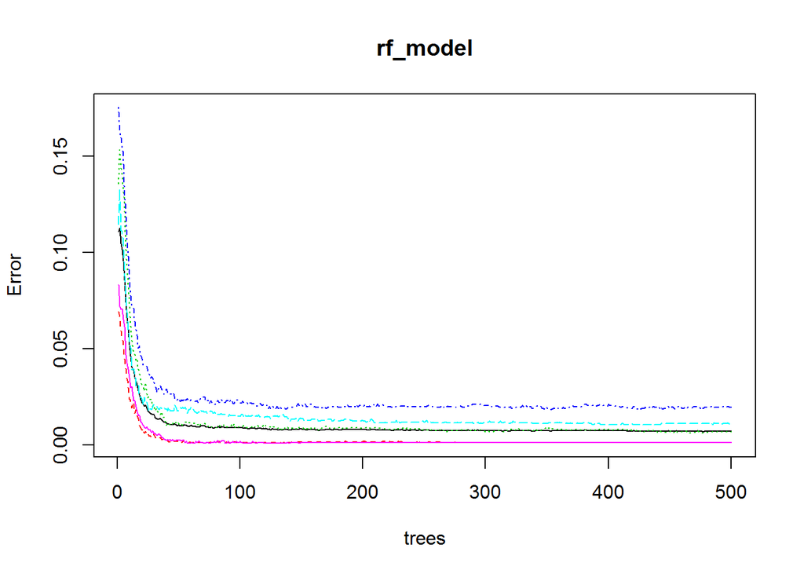

```r
plot(rf_model)
```

```r
predictions <- predict(rf_model, newdata=testing)
confusionMatrix(predictions, testing$outcome)
```

```
## Confusion Matrix and Statistics
##
##           Reference
## Prediction    A    B    C    D    E
##          A 1395    9    1    1    0
##          B    0  937   11    0    0
##          C    0    3  835    8    0
##          D    0    0    8  794    2
##          E    0    0    0    1  899
##
## Overall Statistics
##
##                Accuracy : 0.991
##                  95% CI : (0.988, 0.9935)
##     No Information Rate : 0.2845
##     P-Value [Acc > NIR] : < 2.2e-16
##
##                   Kappa : 0.9886
##  Mcnemar's Test P-Value : NA
##
## Statistics by Class:
##
##                      Class: A Class: B Class: C Class: D Class: E
## Sensitivity            1.0000   0.9874   0.9766   0.9876   0.9978
## Specificity            0.9969   0.9972   0.9973   0.9976   0.9998
## Pos Pred Value         0.9922   0.9884   0.9870   0.9876   0.9989
## Neg Pred Value         1.0000   0.9970   0.9951   0.9976   0.9995
## Prevalence             0.2845   0.1935   0.1743   0.1639   0.1837
## Detection Rate         0.2845   0.1911   0.1703   0.1619   0.1833
## Detection Prevalence   0.2867   0.1933   0.1725   0.1639   0.1835
## Balanced Accuracy      0.9984   0.9923   0.9869   0.9926   0.9988
```

```r
#Quiz predictions using test dataset
#Quiz <- predict(rf_model, newdata=test)
```